# This notebook goes with Lesson 5, Section 14 of the Tensorflow 2.0 course on Udacity.

### This notebook will also create a model that can recognize cats and dogs, but it will use image augmentation (and maybe neuron dropout) to make the model more robust to unforeseen images.

## Import the required packages

```python
import tensorflow as tf
from tensorflow.keras.preprocessing.image import ImageDataGenerator
import os
import numpy as np
import matplotlib.pyplot as plt
```

That should do it.

## Load the data

```python
_URL = 'https://storage.googleapis.com/mledu-datasets/cats_and_dogs_filtered.zip'

zip_dir = tf.keras.utils.get_file('cats_and_dogs_filtered.zip', origin=_URL, extract=True)
```

The data folders have the following structure:

```
cats_and_dogs_filtered
|__ train
    |______ cats: [cat.0.jpg, cat.1.jpg, cat.2.jpg ....]
    |______ dogs: [dog.0.jpg, dog.1.jpg, dog.2.jpg ...]
|__ validation
    |______ cats: [cat.2000.jpg, cat.2001.jpg, cat.2002.jpg ....]
    |______ dogs: [dog.2000.jpg, dog.2001.jpg, dog.2002.jpg ...]
```

```python
base_dir = os.path.join(os.path.dirname(zip_dir), 'cats_and_dogs_filtered')
train_dir = os.path.join(base_dir, 'train')
validation_dir = os.path.join(base_dir, 'validation')
```

```python
train_cats_dir = os.path.join(train_dir, 'cats')
train_dogs_dir = os.path.join(train_dir, 'dogs')
validation_cats_dir = os.path.join(validation_dir, 'cats')
validation_dogs_dir = os.path.join(validation_dir, 'dogs')
```

Now let's have a look at what is going on in those data folders.

```python
num_cats_tr = len(os.listdir(train_cats_dir))
num_dogs_tr = len(os.listdir(train_dogs_dir))

num_cats_val = len(os.listdir(validation_cats_dir))
num_dogs_val = len(os.listdir(validation_dogs_dir))

total_train = num_cats_tr + num_dogs_tr
total_val = num_cats_val + num_dogs_val
```

```python
print('Number of cat training images: ', num_cats_tr)
print('Number of dog training images: ', num_dogs_tr)
print('Number of cat validation images: ', num_cats_val)
print('Number of dog validation images: ', num_dogs_val)
print("---")
print('Total training images: ', total_train)
print('Total validation images: ', total_val)
```

```
Number of cat training images:  1000
Number of dog training images:  1000
Number of cat validation images:  500
Number of dog validation images:  500
---
Total training images:  2000
Total validation images:  1000
```

## Preset Model Parameters

```python
BATCH_SIZE = 100
IMG_SHAPE = 150
```

## Data Augmentation

We only have 2000 training images, 1000 cats and 1000 dogs. This almost surely does not encompass all possible sizes and angles and colors, etc., that pictures of dogs and cats could have. Thus, we will augment the photos we do have in order to artificially inflate the sample size. Augmentations may include rotating the images, flipping them, zooming in or out, and so on.

Let's check out some augmented pictures.

```python
def plotImages(images_arr):
    fig, axes = plt.subplots(1, 5, figsize=(20,20))
    axes = axes.flatten()
    for img, ax in zip(images_arr, axes):
        ax.imshow(img)
    plt.tight_layout()
    plt.show()
```

#### Horizontal flip

```python
image_gen = ImageDataGenerator(rescale=1./255, horizontal_flip=True)

train_data_gen = image_gen.flow_from_directory(batch_size = BATCH_SIZE,
                                              directory=train_dir,
                                              shuffle=True,
                                              target_size=(IMG_SHAPE, IMG_SHAPE))
```

```
Found 2000 images belonging to 2 classes.
```

Now let's look at a picture 5 times, flipping it at random.

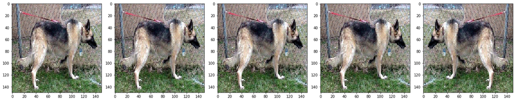

```python
augmented_images = [train_data_gen[0][0][0] for i in range(5)]
plotImages(augmented_images)
```

#### Rotation

```python
image_gen = ImageDataGenerator(rescale=1./255, rotation_range=45)

train_data_gen = image_gen.flow_from_directory(batch_size=BATCH_SIZE,
                                              directory=train_dir,
                                              shuffle=True,
                                              target_size=(IMG_SHAPE, IMG_SHAPE))
```

```
Found 2000 images belonging to 2 classes.
```

Same deal as before, randomly rotating.

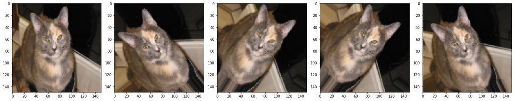

```python
augmented_images = [train_data_gen[0][0][0] for i in range(5)]
plotImages(augmented_images)
```

#### Zoom

```python
image_gen = ImageDataGenerator(rescale=1./255, zoom_range=0.5)

train_data_gen = image_gen.flow_from_directory(batch_size=BATCH_SIZE,
                                              directory=train_dir,
                                              shuffle=True,
                                              target_size=(IMG_SHAPE, IMG_SHAPE))
```

```
Found 2000 images belonging to 2 classes.
```

Once again, randomly zooming.

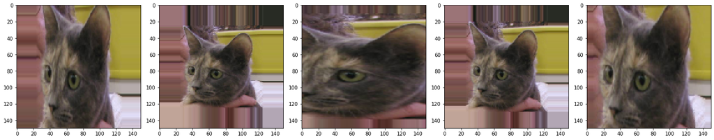

```python
augmented_images = [train_data_gen[0][0][0] for i in range(5)]
plotImages(augmented_images)
```

Looks great! Now let's put it all together.

#### All Augmentations!

```python
image_gen_train = ImageDataGenerator(rescale=1./255,
                                    rotation_range=40,
                                    width_shift_range=0.2,
                                    height_shift_range=0.2,
                                    shear_range=0.2,
                                    zoom_range=0.2,
                                    horizontal_flip=True,
                                    fill_mode='nearest')

train_data_gen = image_gen_train.flow_from_directory(batch_size=BATCH_SIZE,
                                                    directory=train_dir,
                                                    shuffle=True,
                                                    target_size=(IMG_SHAPE,IMG_SHAPE),
                                                    class_mode='binary')
```

```
Found 2000 images belonging to 2 classes.
```

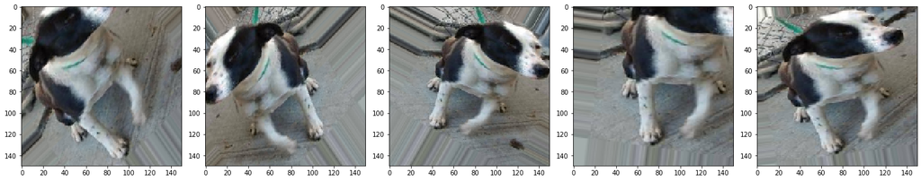

```python
augmented_images = [train_data_gen[0][0][0] for i in range(5)]
plotImages(augmented_images)
```

### Validation Data Generator

```python
image_gen_val = ImageDataGenerator(rescale=1./255)

val_data_gen = image_gen_val.flow_from_directory(batch_size=BATCH_SIZE,
                                                directory=validation_dir,
                                                target_size=(IMG_SHAPE,IMG_SHAPE),
                                                class_mode='binary')
```

```
Found 1000 images belonging to 2 classes.
```

## Create the model

We are going to use a Convolutional Neural Network on this augmented data. It will look similar to the last CNN; Four pairs of Conv2D & MaxPooling2D layers, **then a Dropout layer**, then Flatten, then a Dense Relu layer and then the final Dense layer.

```python
model = tf.keras.models.Sequential([
    tf.keras.layers.Conv2D(32, (3,3), activation='relu', input_shape=(150, 150, 3)),
    tf.keras.layers.MaxPooling2D(2, 2),

    tf.keras.layers.Conv2D(64, (3,3), activation='relu'),
    tf.keras.layers.MaxPooling2D(2,2),

    tf.keras.layers.Conv2D(128, (3,3), activation='relu'),
    tf.keras.layers.MaxPooling2D(2,2),

    tf.keras.layers.Conv2D(128, (3,3), activation='relu'),
    tf.keras.layers.MaxPooling2D(2,2),

    tf.keras.layers.Dropout(0.5),
    tf.keras.layers.Flatten(),
    tf.keras.layers.Dense(512, activation='relu'),
    tf.keras.layers.Dense(2)
])
```

### Compile the model

```python
model.compile(optimizer = 'adam',
             loss = tf.keras.losses.SparseCategoricalCrossentropy(from_logits=True),
             metrics=['accuracy'])
```

### Model Summary

```python
model.summary()
```

```
Model: "sequential"
_________________________________________________________________
Layer (type)                 Output Shape              Param #
=================================================================
conv2d (Conv2D)              (None, 148, 148, 32)      896
_________________________________________________________________
max_pooling2d (MaxPooling2D) (None, 74, 74, 32)        0
_________________________________________________________________
conv2d_1 (Conv2D)            (None, 72, 72, 64)        18496
_________________________________________________________________
max_pooling2d_1 (MaxPooling2 (None, 36, 36, 64)        0
_________________________________________________________________
conv2d_2 (Conv2D)            (None, 34, 34, 128)       73856
_________________________________________________________________
max_pooling2d_2 (MaxPooling2 (None, 17, 17, 128)       0
_________________________________________________________________
conv2d_3 (Conv2D)            (None, 15, 15, 128)       147584
_________________________________________________________________
max_pooling2d_3 (MaxPooling2 (None, 7, 7, 128)         0
_________________________________________________________________
dropout (Dropout)            (None, 7, 7, 128)         0
_________________________________________________________________
flatten (Flatten)            (None, 6272)              0
_________________________________________________________________
dense (Dense)                (None, 512)               3211776
_________________________________________________________________
dense_1 (Dense)              (None, 2)                 1026
=================================================================
Total params: 3,453,634
Trainable params: 3,453,634
Non-trainable params: 0
_________________________________________________________________
```

### Train the Model

```python
epochs = 100
history = model.fit_generator(train_data_gen,
                             steps_per_epoch=int(np.ceil(total_train / float(BATCH_SIZE))),
                             epochs = epochs,
                             validation_data = val_data_gen,
                             validation_steps = int(np.ceil(total_val / float(BATCH_SIZE))))
```

Now that the model has been trained, let's check out the loss and accuracy to see if we're getting overfitting.

## Visualizing Metrics

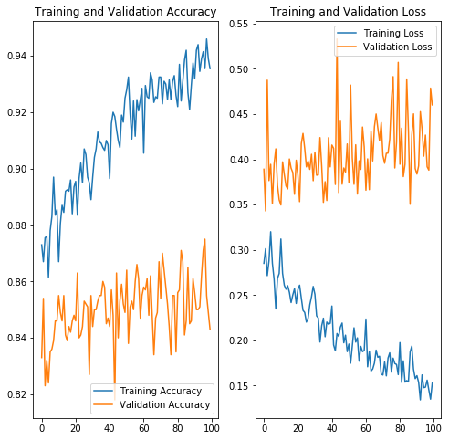

```python
acc = history.history['accuracy']
val_acc = history.history['val_accuracy']

loss = history.history['loss']
val_loss = history.history['val_loss']

epochs_range = range(epochs)

plt.figure(figsize=(8,8))
plt.subplot(1, 2, 1)
plt.plot(epochs_range, acc, label='Training Accuracy')
plt.plot(epochs_range, val_acc, label='Validation Accuracy')
plt.legend(loc='lower right')
plt.title('Training and Validation Accuracy')

plt.subplot(1, 2, 2)
plt.plot(epochs_range, loss, label='Training Loss')
plt.plot(epochs_range, val_loss, label='Validation Loss')
plt.legend(loc='upper right')
plt.title('Training and Validation Loss')

plt.show()
```